# Model Performance Analysis

Samuel N. Araya

25 June, 2019

# RF Model Performances

The testing set was split based on random unique combinations of date and transect without replacement into approximately 0.75:0.25 training:testing set split (i.e., 300:100 records).

The testing set was used as a hold-out set and used only to evaluate final trained models. The testing set was subset based on random unique combinations of three sampling dates and two transects without replacement. This method was adopted to ensure that the testing and training samples were not too similar because of spatial autocorrelation, which would result if a simple random splitting was done. Furthermore, to check for possible bias that may result from training:testing set split, we randomly generated 30 unique training-testing set splits and trained 30 models based on the 30 training sets and tested the model performance on their respective testing sets.

## Model Performances Summaries

### Absolute Residual of models sorted by MAE

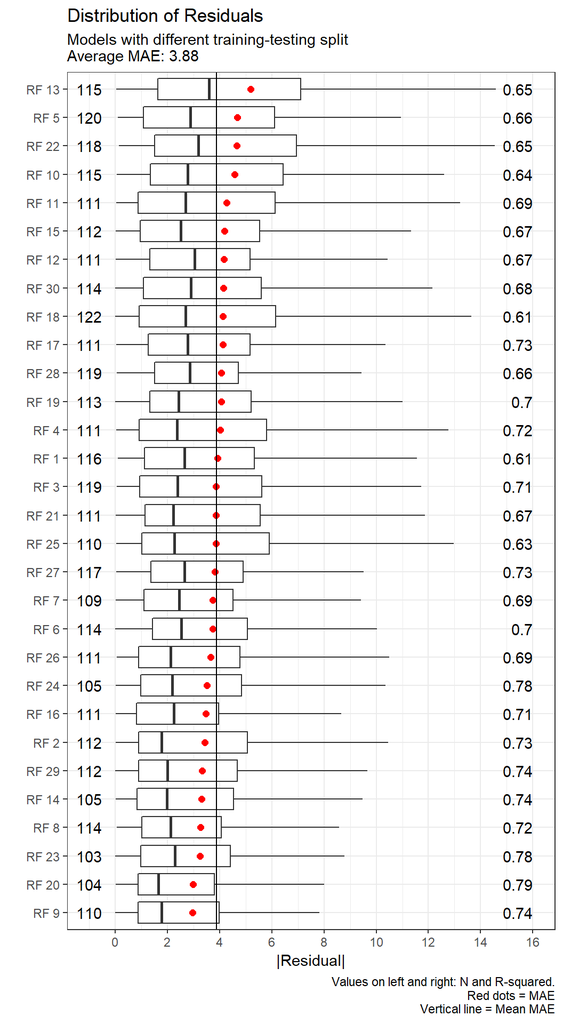

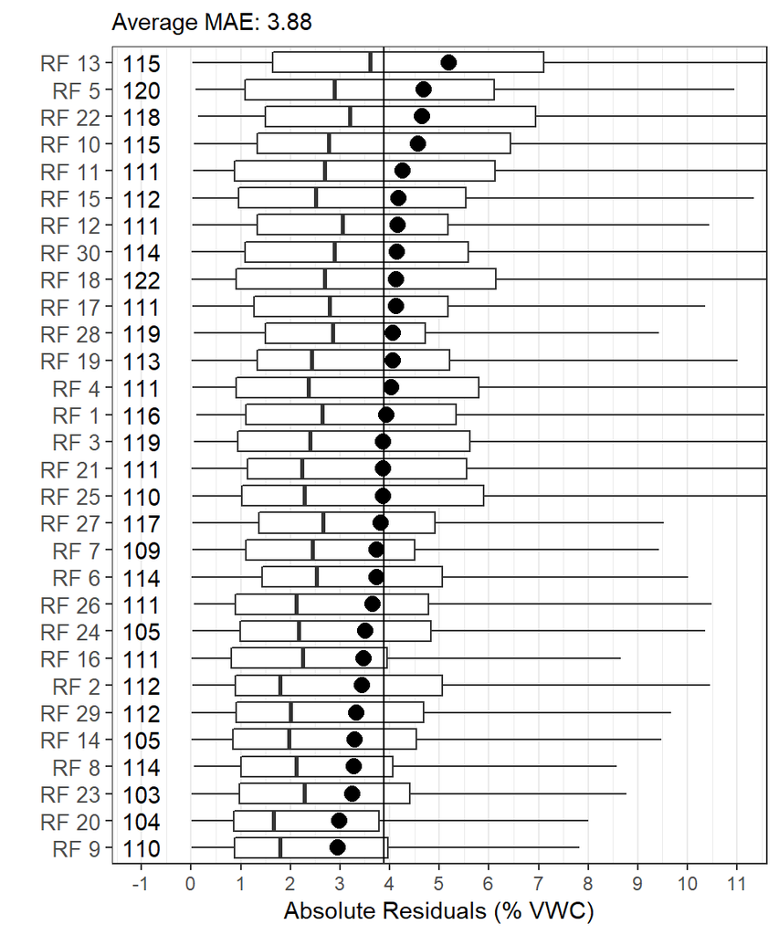

### Predicted vs. Measured Plot

Combined one to one plot with ensemble performance metrics

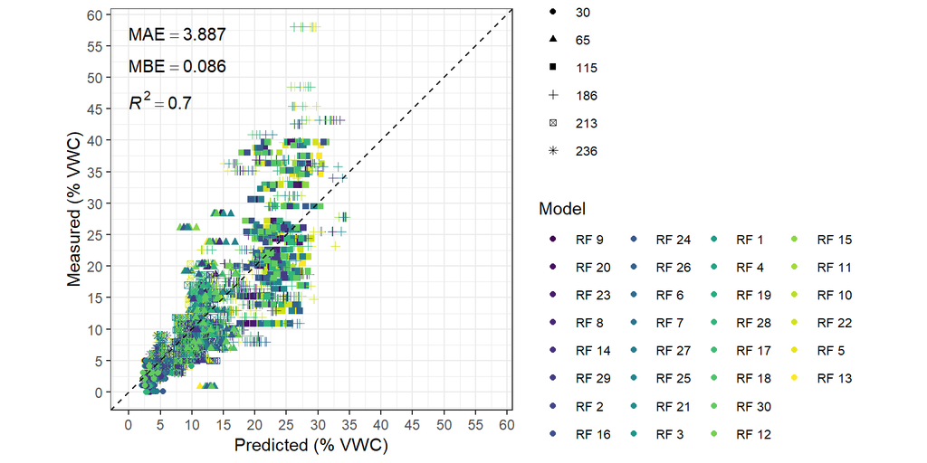

Individual models: Color plot

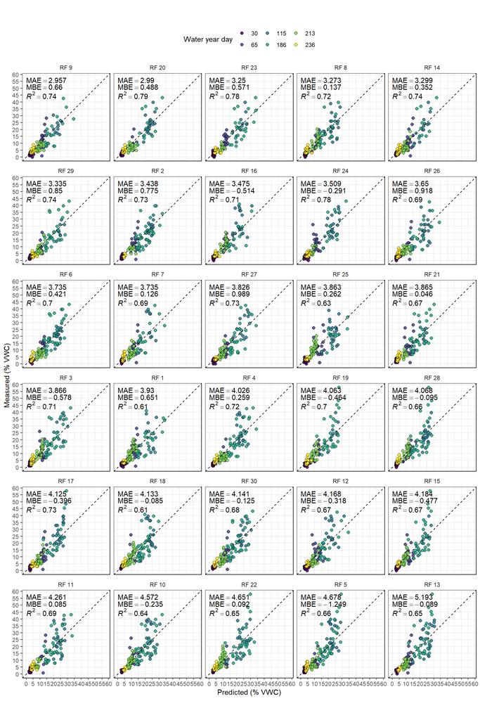

Individual models: Black and white

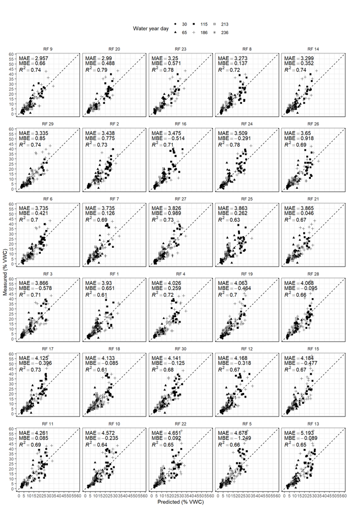

### Variable Importance

Model specific variable importance.

Top 25 Variables

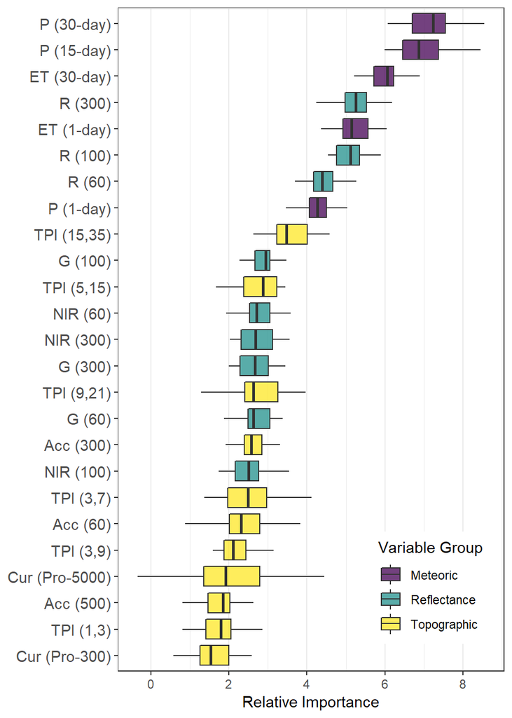

Summation of all variables grouped by type

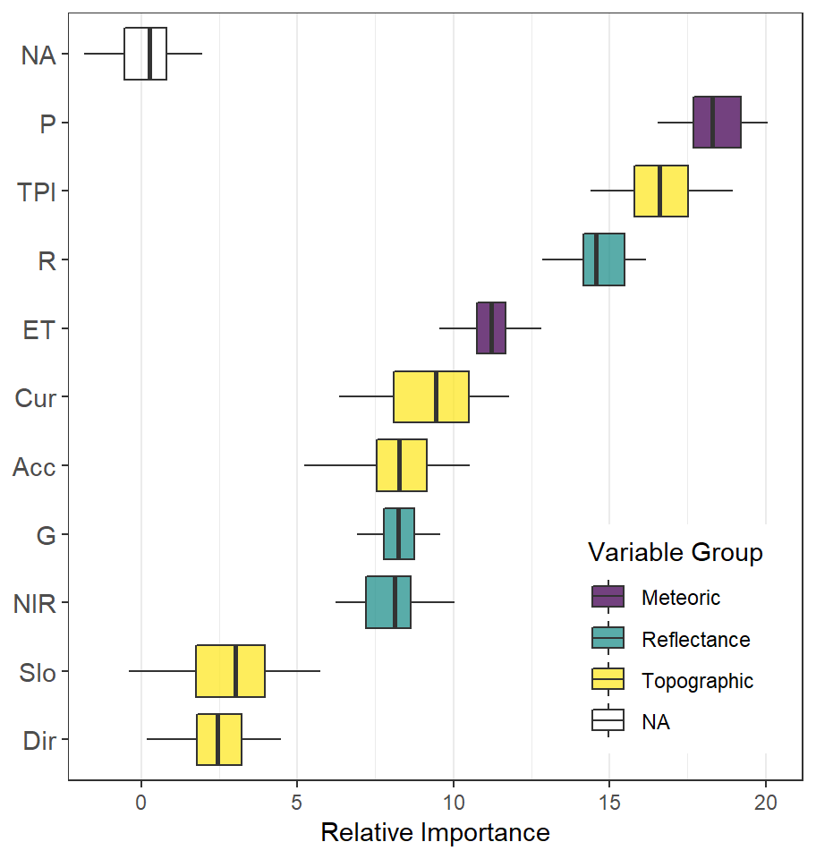

Mean of all variables grouped by type

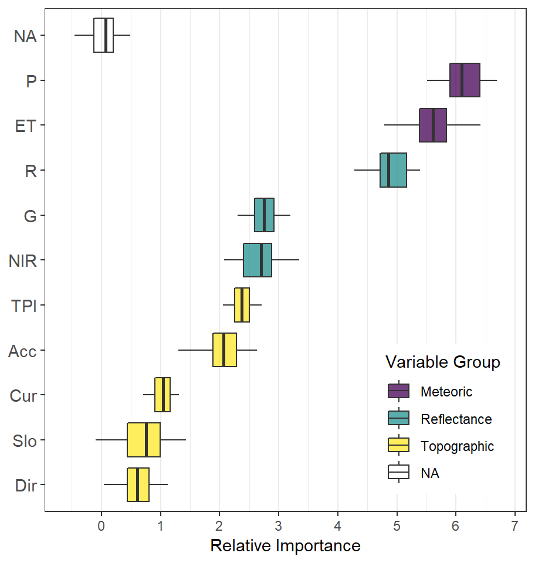

### Variable Effect

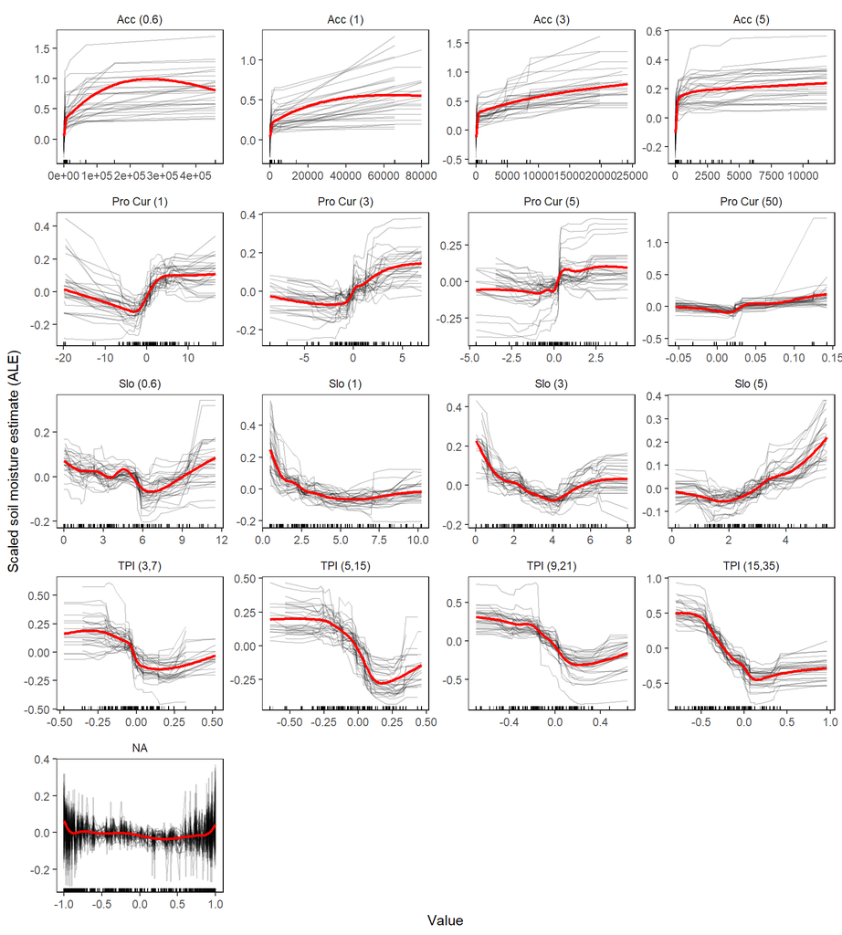

#### Tuning summaries for best models

Best tuning parameters

| id | mtry | label | label_ordered |
| --- | --- | --- | --- |
| 1 | 7 | RF 1 | RF 1 |
| 2 | 6 | RF 2 | RF 2 |
| 3 | 9 | RF 3 | RF 3 |
| 4 | 9 | RF 4 | RF 4 |
| 5 | 14 | RF 5 | RF 5 |
| 6 | 6 | RF 6 | RF 6 |
| 7 | 7 | RF 7 | RF 7 |
| 8 | 6 | RF 8 | RF 8 |
| 9 | 7 | RF 9 | RF 9 |
| 10 | 7 | RF 10 | RF 10 |
| 11 | 7 | RF 11 | RF 11 |
| 12 | 7 | RF 12 | RF 12 |
| 13 | 11 | RF 13 | RF 13 |
| 14 | 6 | RF 14 | RF 14 |
| 15 | 7 | RF 15 | RF 15 |
| 16 | 7 | RF 16 | RF 16 |
| 17 | 9 | RF 17 | RF 17 |
| 18 | 9 | RF 18 | RF 18 |
| 19 | 7 | RF 19 | RF 19 |
| 20 | 6 | RF 20 | RF 20 |
| 21 | 6 | RF 21 | RF 21 |
| 22 | 17 | RF 22 | RF 22 |
| 23 | 7 | RF 23 | RF 23 |
| 24 | 7 | RF 24 | RF 24 |
| 25 | 7 | RF 25 | RF 25 |
| 26 | 7 | RF 26 | RF 26 |
| 27 | 7 | RF 27 | RF 27 |
| 28 | 7 | RF 28 | RF 28 |
| 29 | 8 | RF 29 | RF 29 |
| 30 | 7 | RF 30 | RF 30 |

Tuning plots

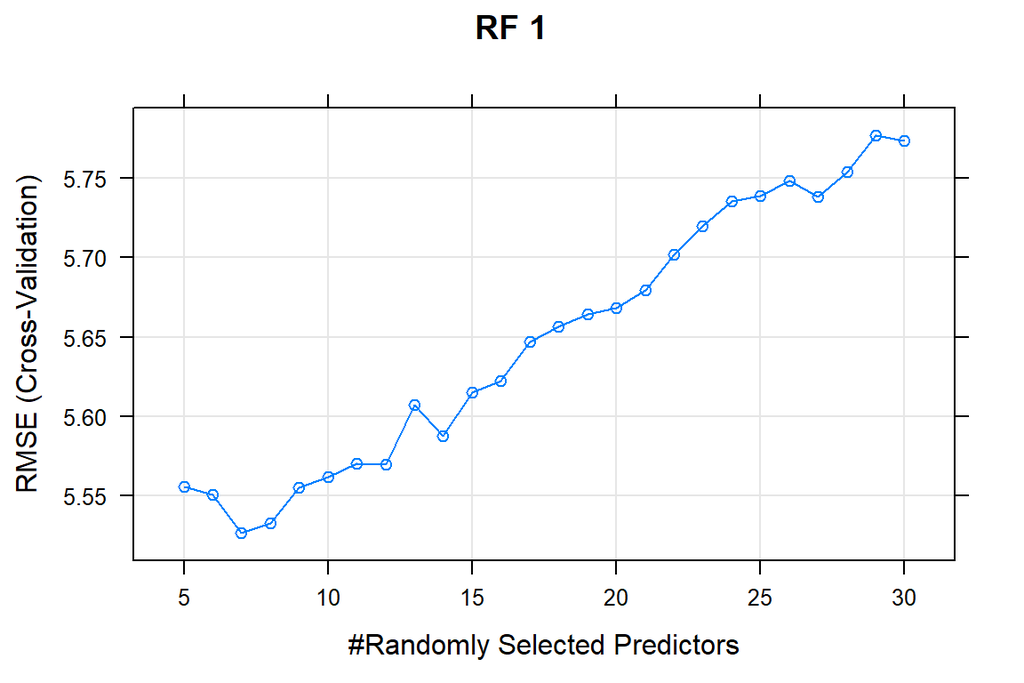

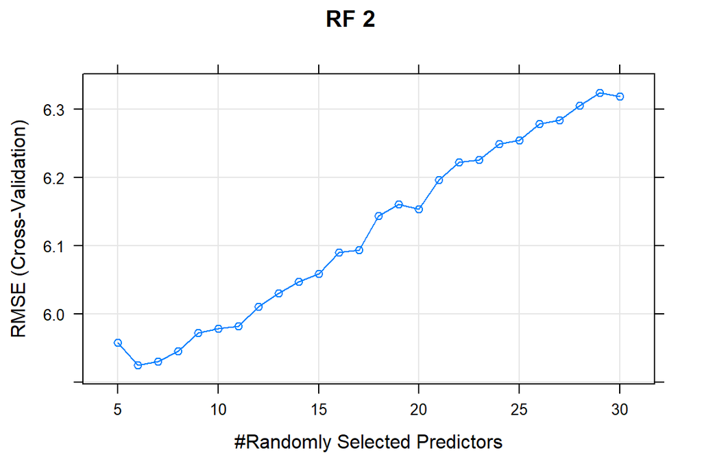

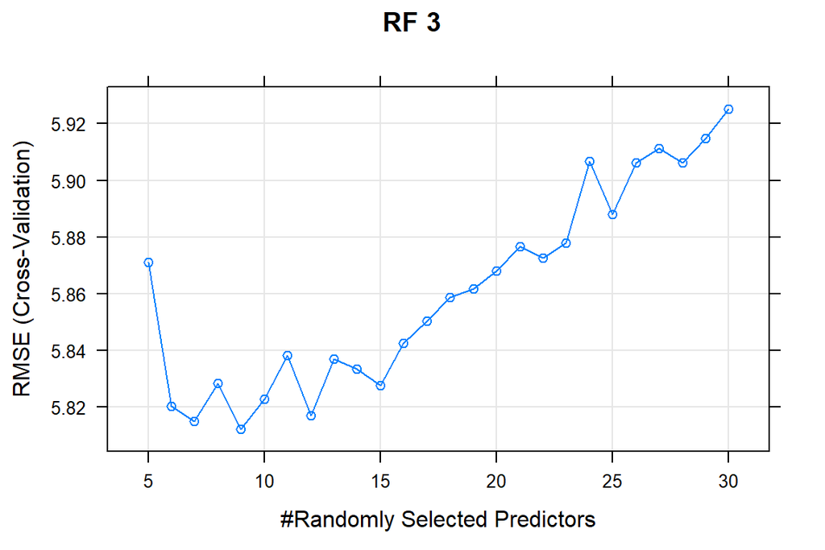

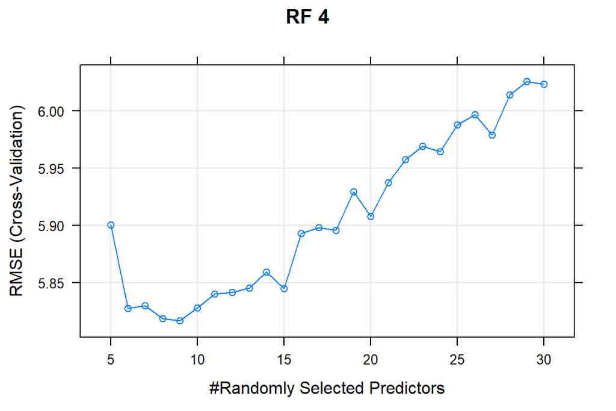

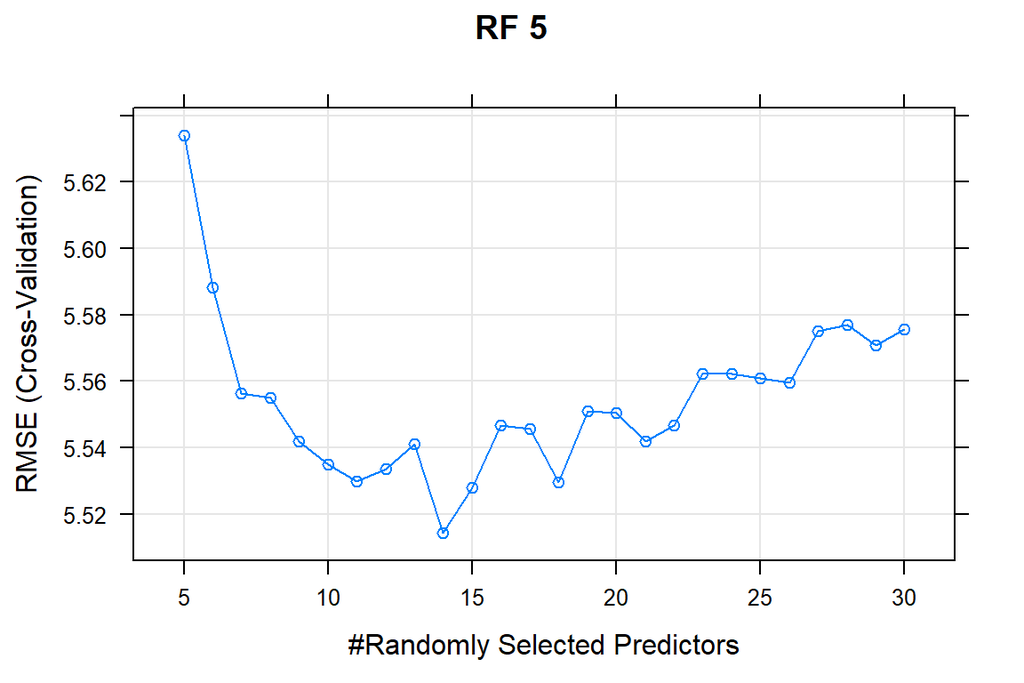

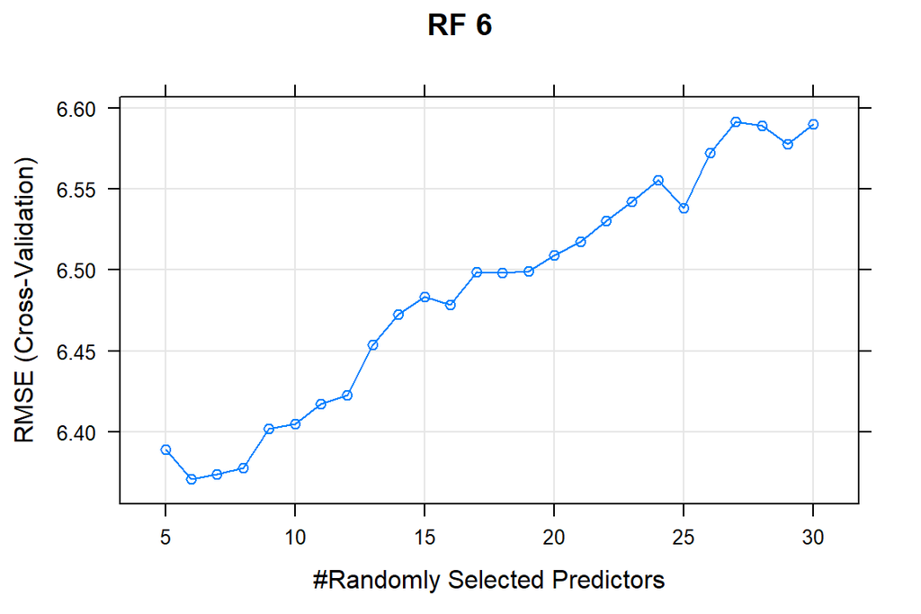

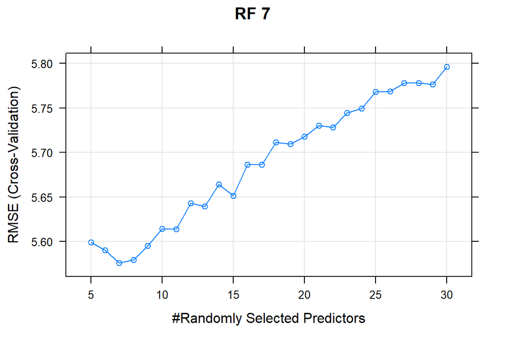

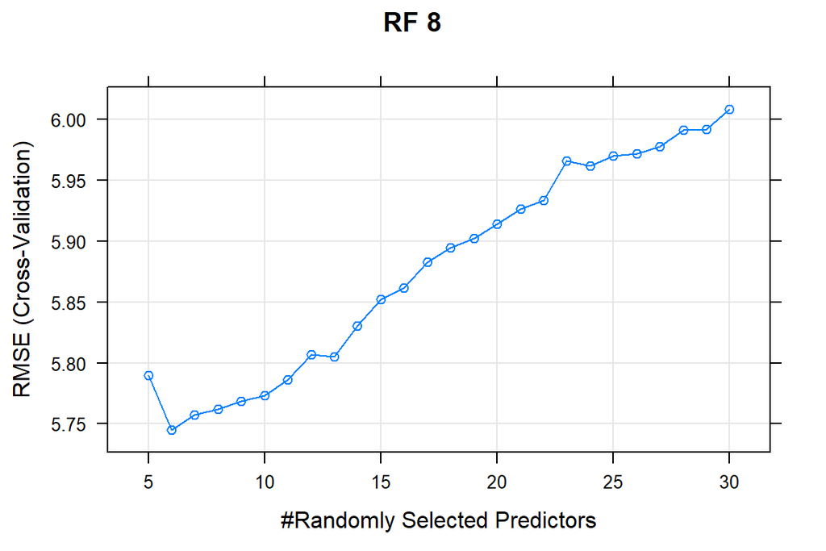

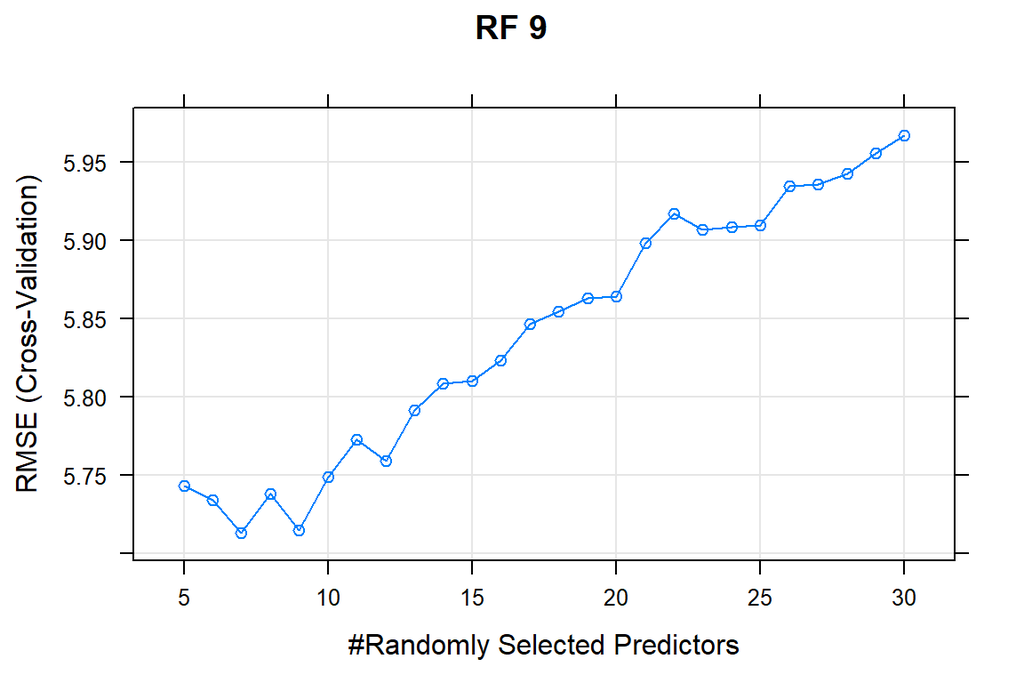

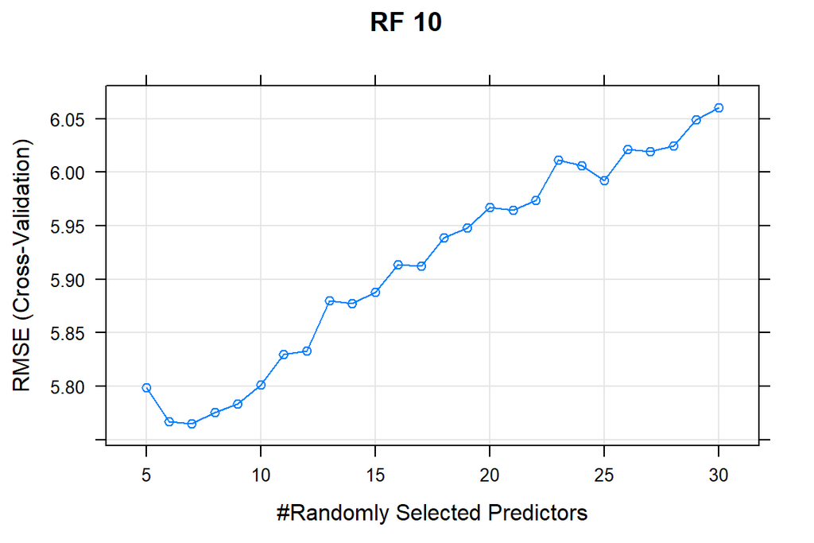

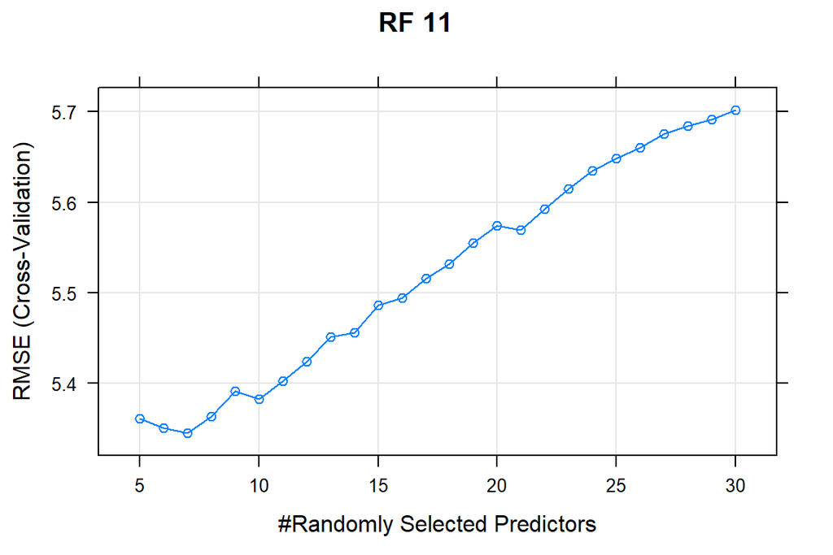

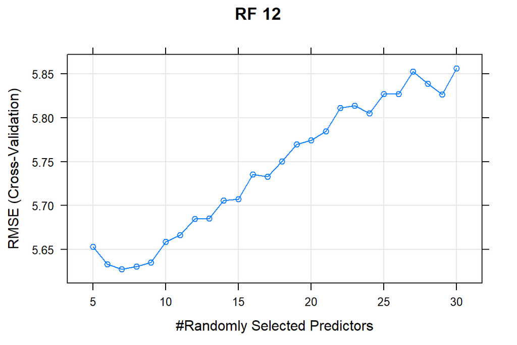

[18 more figures not shown]

## Detailed Model Performances

| label | rmse | mae | mbe | r2 | r2.fmt | n | res_q1 | res_q3 | res_iqr | mae_txt | mbe_txt | r2_txt | label_ordered |
| --- | --- | --- | --- | --- | --- | --- | --- | --- | --- | --- | --- | --- | --- |
| RF 1 | 5.6104 | 3.9300 | 0.6514 | 0.6136 | 0.61 | 116 | -1.9673 | 3.2558 | 5.2231 | MAE==3.93 | MBE==0.651 | italic(R) ^ 2 == 0.61 | RF 1 |
| RF 10 | 6.4457 | 4.5716 | -0.2353 | 0.6380 | 0.64 | 115 | -2.5147 | 2.8975 | 5.4121 | MAE==4.572 | MBE==-0.235 | italic(R) ^ 2 == 0.64 | RF 10 |
| RF 11 | 6.1326 | 4.2605 | 0.0852 | 0.6894 | 0.69 | 111 | -1.8639 | 3.3299 | 5.1938 | MAE==4.261 | MBE==0.085 | italic(R) ^ 2 == 0.69 | RF 11 |
| RF 12 | 5.9724 | 4.1680 | -0.3177 | 0.6656 | 0.67 | 111 | -1.9987 | 3.4306 | 5.4294 | MAE==4.168 | MBE==-0.318 | italic(R) ^ 2 == 0.67 | RF 12 |
| RF 13 | 7.2226 | 5.1929 | -0.0895 | 0.6494 | 0.65 | 115 | -2.4468 | 4.0137 | 6.4604 | MAE==5.193 | MBE==-0.089 | italic(R) ^ 2 == 0.65 | RF 13 |
| RF 14 | 4.8302 | 3.2992 | 0.3519 | 0.7355 | 0.74 | 105 | -1.0082 | 2.7880 | 3.7962 | MAE==3.299 | MBE==0.352 | italic(R) ^ 2 == 0.74 | RF 14 |
| RF 15 | 6.5303 | 4.1841 | -0.4773 | 0.6683 | 0.67 | 112 | -1.9249 | 2.7559 | 4.6808 | MAE==4.184 | MBE==-0.477 | italic(R) ^ 2 == 0.67 | RF 15 |
| RF 16 | 5.3900 | 3.4746 | -0.5141 | 0.7139 | 0.71 | 111 | -2.0003 | 2.2714 | 4.2717 | MAE==3.475 | MBE==-0.514 | italic(R) ^ 2 == 0.71 | RF 16 |
| RF 17 | 6.0425 | 4.1248 | -0.3961 | 0.7323 | 0.73 | 111 | -2.0406 | 3.1888 | 5.2294 | MAE==4.125 | MBE==-0.396 | italic(R) ^ 2 == 0.73 | RF 17 |
| RF 18 | 6.1016 | 4.1333 | -0.0850 | 0.6068 | 0.61 | 122 | -1.6705 | 3.2920 | 4.9625 | MAE==4.133 | MBE==-0.085 | italic(R) ^ 2 == 0.61 | RF 18 |
| RF 19 | 6.3017 | 4.0632 | -0.4644 | 0.6991 | 0.70 | 113 | -1.9783 | 2.5523 | 4.5306 | MAE==4.063 | MBE==-0.464 | italic(R) ^ 2 == 0.7 | RF 19 |
| RF 2 | 4.9460 | 3.4380 | 0.7751 | 0.7260 | 0.73 | 112 | -0.7177 | 2.7580 | 3.4757 | MAE==3.438 | MBE==0.775 | italic(R) ^ 2 == 0.73 | RF 2 |
| RF 20 | 4.4972 | 2.9904 | 0.4882 | 0.7909 | 0.79 | 104 | -0.5994 | 2.7486 | 3.3479 | MAE==2.99 | MBE==0.488 | italic(R) ^ 2 == 0.79 | RF 20 |
| RF 21 | 5.5948 | 3.8651 | 0.0457 | 0.6700 | 0.67 | 111 | -1.3825 | 2.7222 | 4.1047 | MAE==3.865 | MBE==0.046 | italic(R) ^ 2 == 0.67 | RF 21 |
| RF 22 | 6.5154 | 4.6508 | 0.0920 | 0.6451 | 0.65 | 118 | -2.5808 | 3.5156 | 6.0964 | MAE==4.651 | MBE==0.092 | italic(R) ^ 2 == 0.65 | RF 22 |
| RF 23 | 4.6324 | 3.2501 | 0.5713 | 0.7828 | 0.78 | 103 | -0.9373 | 2.8304 | 3.7677 | MAE==3.25 | MBE==0.571 | italic(R) ^ 2 == 0.78 | RF 23 |
| RF 24 | 5.0381 | 3.5091 | -0.2913 | 0.7764 | 0.78 | 105 | -1.6960 | 2.3026 | 3.9985 | MAE==3.509 | MBE==-0.291 | italic(R) ^ 2 == 0.78 | RF 24 |
| RF 25 | 5.4719 | 3.8632 | 0.2620 | 0.6274 | 0.63 | 110 | -2.0718 | 2.4169 | 4.4887 | MAE==3.863 | MBE==0.262 | italic(R) ^ 2 == 0.63 | RF 25 |
| RF 26 | 5.3651 | 3.6496 | 0.9179 | 0.6865 | 0.69 | 111 | -1.0688 | 2.9290 | 3.9977 | MAE==3.65 | MBE==0.918 | italic(R) ^ 2 == 0.69 | RF 26 |
| RF 27 | 5.1893 | 3.8262 | 0.9887 | 0.7325 | 0.73 | 117 | -0.8137 | 3.7537 | 4.5674 | MAE==3.826 | MBE==0.989 | italic(R) ^ 2 == 0.73 | RF 27 |
| RF 28 | 6.1609 | 4.0676 | -0.0948 | 0.6632 | 0.66 | 119 | -2.4042 | 2.9403 | 5.3445 | MAE==4.068 | MBE==-0.095 | italic(R) ^ 2 == 0.66 | RF 28 |
| RF 29 | 4.8835 | 3.3350 | 0.8498 | 0.7370 | 0.74 | 112 | -0.4212 | 2.9949 | 3.4161 | MAE==3.335 | MBE==0.85 | italic(R) ^ 2 == 0.74 | RF 29 |
| RF 3 | 5.5166 | 3.8656 | -0.5783 | 0.7109 | 0.71 | 119 | -2.5922 | 1.9706 | 4.5628 | MAE==3.866 | MBE==-0.578 | italic(R) ^ 2 == 0.71 | RF 3 |
| RF 30 | 5.7729 | 4.1411 | -0.1245 | 0.6779 | 0.68 | 114 | -2.4439 | 2.9997 | 5.4437 | MAE==4.141 | MBE==-0.125 | italic(R) ^ 2 == 0.68 | RF 30 |
| RF 4 | 5.8334 | 4.0256 | 0.2587 | 0.7158 | 0.72 | 111 | -0.8748 | 3.4777 | 4.3525 | MAE==4.026 | MBE==0.259 | italic(R) ^ 2 == 0.72 | RF 4 |
| RF 5 | 6.9871 | 4.6776 | -1.2485 | 0.6621 | 0.66 | 120 | -2.6649 | 3.0673 | 5.7322 | MAE==4.678 | MBE==-1.249 | italic(R) ^ 2 == 0.66 | RF 5 |
| RF 6 | 5.2431 | 3.7345 | 0.4215 | 0.6990 | 0.70 | 114 | -1.7163 | 2.8430 | 4.5593 | MAE==3.735 | MBE==0.421 | italic(R) ^ 2 == 0.7 | RF 6 |
| RF 7 | 5.4437 | 3.7347 | 0.1263 | 0.6891 | 0.69 | 109 | -1.5822 | 2.8211 | 4.4033 | MAE==3.735 | MBE==0.126 | italic(R) ^ 2 == 0.69 | RF 7 |
| RF 8 | 4.7389 | 3.2726 | 0.1366 | 0.7175 | 0.72 | 114 | -1.9936 | 2.2149 | 4.2085 | MAE==3.273 | MBE==0.137 | italic(R) ^ 2 == 0.72 | RF 8 |
| RF 9 | 4.3055 | 2.9572 | 0.6603 | 0.7379 | 0.74 | 110 | -0.8112 | 2.4989 | 3.3101 | MAE==2.957 | MBE==0.66 | italic(R) ^ 2 == 0.74 | RF 9 |